# Longitudinal Data Analysis General Framework

Yue Harriet Huang

March 25, 2016

install.packages(“reshape2”) install.packages(“data.table”) install.packages(“lattice”) install.packages(“ggplot2”)

## Design:

### * Repeated Measures: response measured repeatedly on a set of units (individuals)

### * Balanced Dataset: each individual measured at the same set of ages

### * Unbalanced dataset: each individual measured at different set of ages

## Research questions we can answer:

### * How does change of treatment (predictors) affect growth over time within the same individual

### * How does change of treatment (predictors) affect growth between individuals (Control Group versus Test Group)

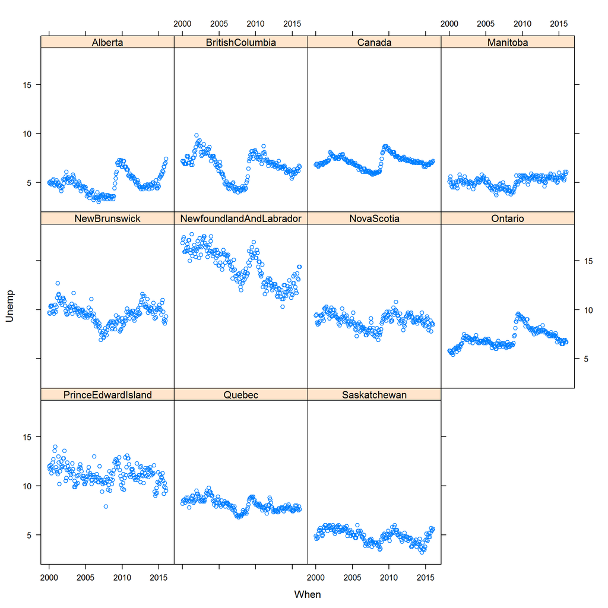

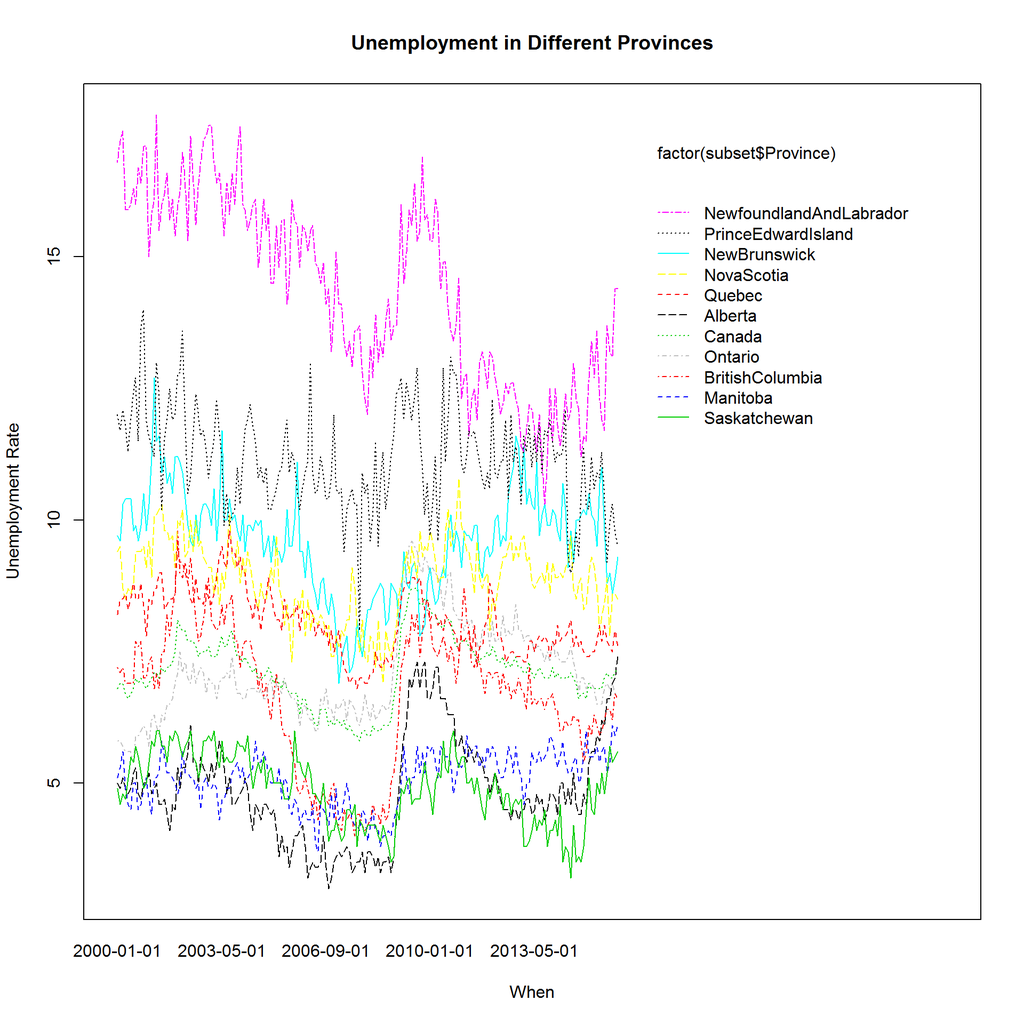

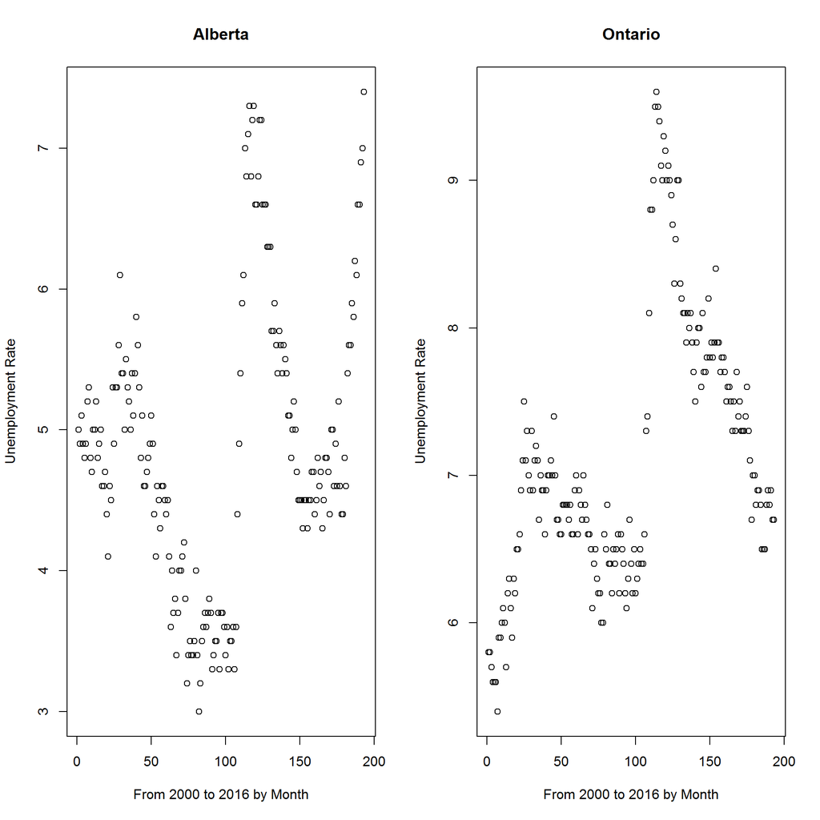

## Observe from plots:

### 1. Variability within individuals: usually correlated

### 2. Variability between individuals

## 1. Model Variability within individual over time: 1st level model

### (1) Firstly try a linear model on each of the growth trajectory:

#### Recall Assumptions of OLS linear model:

```
* independent between observations
```

#### which apparently does not make sense:

```
* clear nonlinearity in each of the growth curve

* observations within an individual are correlated

* but we can see that each curve has different intercept and slope
```

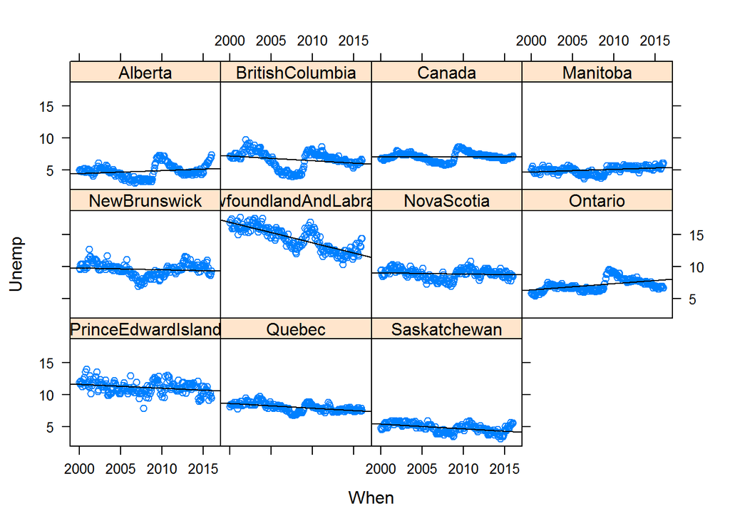

## Choose Fixed Effects Model or Random Effects Model

### Fixed Effects Model:

- Fixed model cannot generalize to new individuals in the population, only to ‘new’ observations from the same individuals. In our case, this is appropriate, because Canada has a fixed number of provinces, we do not need to generalize to newer individuals (provinces) outside of our sample, otherwise we will use a Random effects model to generalized to the population.

## $$\beta_{i0} = \phi_{00} + \phi_{01}Location_{i} + \zeta_{0i}$$

```
##
##                            BC East Maritime Prairie
##   Alberta                   0    0        0     193
##   BritishColumbia         193    0        0       0
##   Canada                    0    0        0       0
##   Manitoba                  0    0        0     193
##   NewBrunswick              0    0      193       0
##   NewfoundlandAndLabrador   0    0      193       0
##   NovaScotia                0    0      193       0
##   Ontario                   0  193        0       0
##   PrinceEdwardIsland        0    0      193       0
##   Quebec                    0  193        0       0
##   Saskatchewan              0    0        0     193
```